# Takvim Tabanlı Grafikler

ozge.ozdamar@msgsu.edu.tr

October 28 2021

**REFERENCES**

https://r-coder.com/calendar-plot-r/

https://www.garrickadenbuie.com/blog/r-console-calendar/

https://cran.rstudio.com/web/packages/sugrrants/vignettes/frame-calendar.html

[calendarHeat Function](https://raw.githubusercontent.com/iascchen/VisHealth/master/R/calendarHeat.R)

**LIBRARIES**

```r
.packages = c("googleVis", "openair", "calendR","sugrrants")
.inst <- .packages %in% installed.packages()
if(length(.packages[!.inst]) > 0) install.packages(.packages[!.inst])
lapply(.packages, require, character.only=TRUE)
```

**FUNCTIONS**

```r
calendar::x
calendR::calendR()
googleVis::gvisCalendar()
openair::calendarPlot()
```

Sınırlı bir zaman aralığında gözlemlenen değerleri görselleştirmek için kullanılan yöntemlerden biri de takvim tabanlı grafikler (Wang, Cook, and Hyndman 2020) oluşturmaktır. Bu yaklaşımda, görselleştirilecek zaman aralığı için bir çizelge(takvim) oluştur. Bu çizelgenin her hücresi bir zaman aralığını ifade eder ve hücrelerin içine her hücrenin kendi zaman aralığı için “görsel bilgi” yerleştirilir. Gündelik hayatta kullandığımız takvimler, hücreleri bir günü ifade eden çizelgeler olduğundan, çoğunlukla da bu tasarımla karşılaşırız.

Takvim tabanlı grafiklerde hücre içindeki “görsel bilgi”; grafiğin tasarımına göre farklılık gösterebilir. Bu bilgi, hücrenin ifade ettiği zaman aralığında tek bir gözlemin olması durumunda o gözleme ait değerinin renkle kodlanması, birden fazla gözlemin olması durumunda ise bir grafik olabilir.

Takvim tabanlı grafikleri oluşturabilmek için öncelikle elimizdeki veri setinin yapısının buna uygun olması gerekmektedir. R’da zaman farklı yapı ve nesnelerle tutulabildiğinden öncelikle bu konularda bilgi tamamlaması için (BKNZ:R’DA ZAMAN) bölümünü inceleyiniz.

# 1 R’da Takvim Oluşturmak

R, Unix ya da MacOS iştetim sistemi üzerine kurulu ise güncel takvimi sistemden `system("cal")` ve `system("cal 2021")` fonksiyonları ile konsol üzerinde oluşturabiliriz. Ancak bu fonksiyonlar Windows için çalışmayacaktır ve takvim konsol üzerinde oluştuğundan görselleştirme yapmak için elverişsiz olacaktır.

İstenilen tasarımda takvim oluşturmak için `calendR`, oldukça elverişli bir pakettir. Takvim üzerindeki gün ve ay isimleri sistemin kullandığı dilde olacağından, `Sys.setlocale` foksiyonu kullanılarak takvim metinleri istenilen dile çevrilebilir.

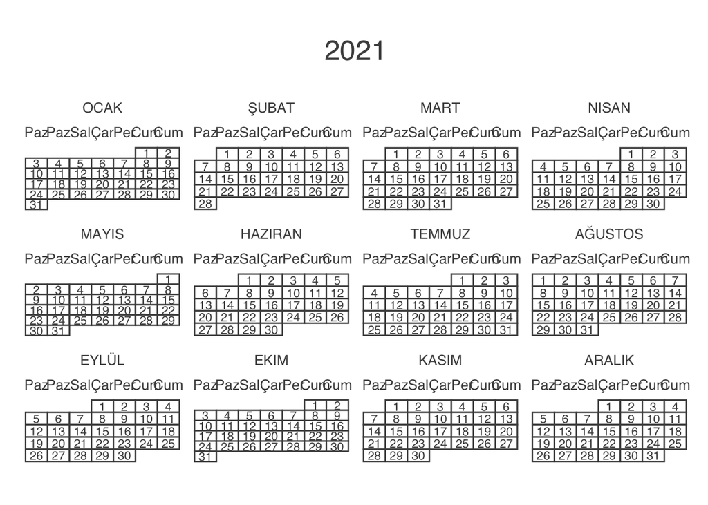

```r
# system("locale -a")
Sys.setlocale("LC_TIME", "tr_TR") # Türkçe ay ve gün isimleri için
calendR()
```

Bir de aylık şablon oluşturalım:

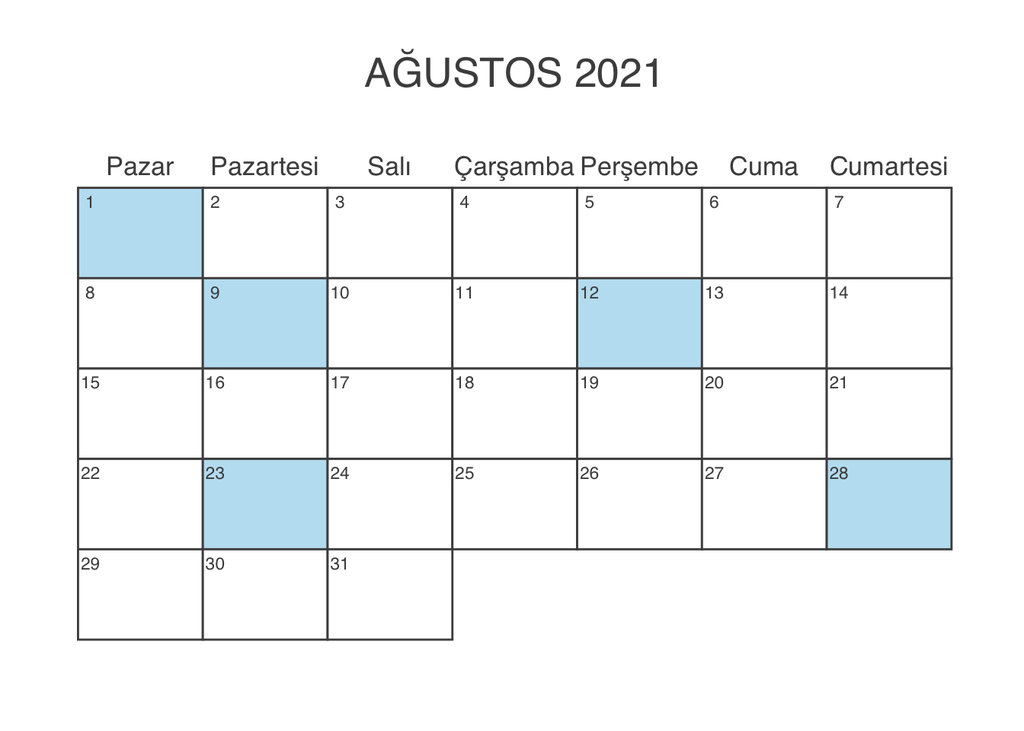

```r
calendR(year = 2021, month = 8, special.days = c(1, 9, 12, 23, 28), special.col = "#bfe2f2", low.col = "white")
```

# 2 Takvim Isı Grafiği (calendar heatmap)

Mintz ve arkadaşları, 1997 yılındaki SAS konferansında sundukları bildiride; takvim üzerinde gözlem değerleri renkle kodlayarak oluşturdukları grafiğe *Tile Map* ismini vermişlerdir (Mintz, Fitz-Simons, and Wayland 1997). Ancak bu isim ilerleyen yıllarda, tile plot ve calender plot’un haritalar üzerinde yerleştirlerek yapılan görselleştirmeler için kullanılmaya başlamıştır. Takvim Isı Grafiği *(ing:calendar heatmap)* ismi kullanılmaktadır.

Fonksiyonun argümanları;

```r
source("https://raw.githubusercontent.com/iascchen/VisHealth/master/R/calendarHeat.R")
```

calendarHeat() makes the process much easier. We just need to call the function and specify the below five arguments.

**date:** Dates for which the data needs to be plotted. **values:** Values associated with those dates. **color:** Renk paleti, Default r2g *red to green*, r2b *red to blue* ya da w2b *white to blue* . vektör olarak kendi renk paletinizi de oluşturabiliriz **ncolors:** Number of colors for the heatmap **varname:** Grafik başlığı

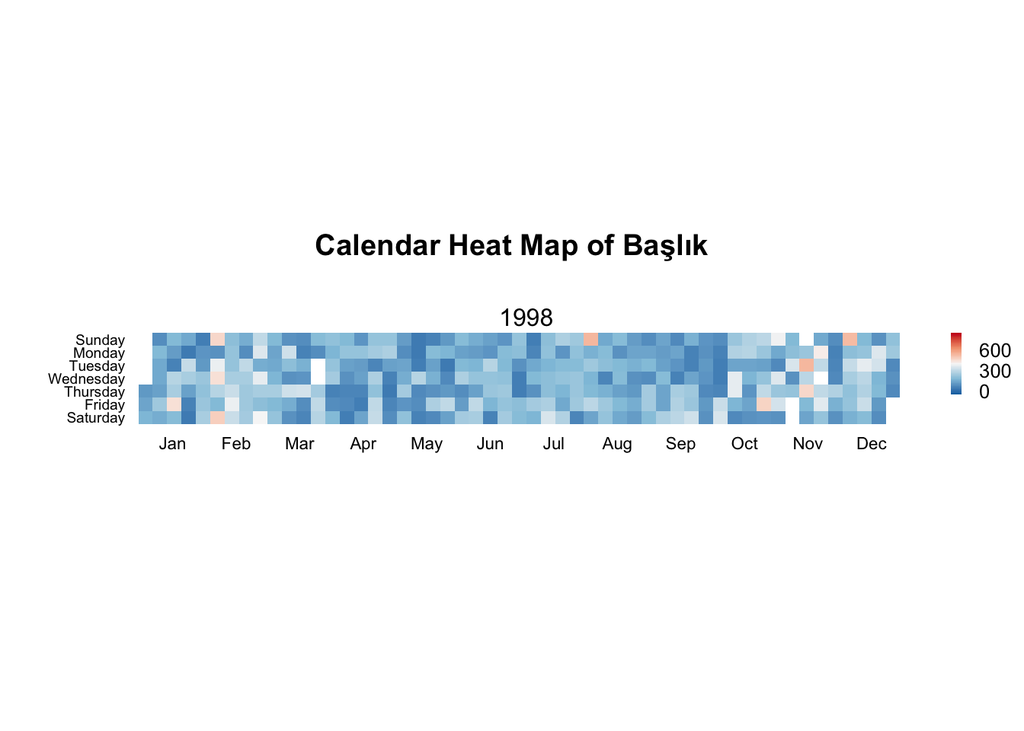

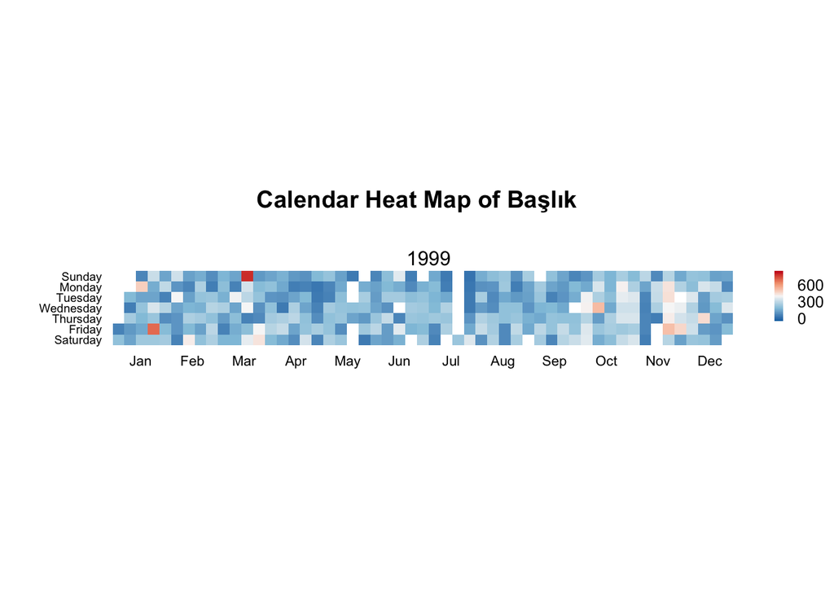

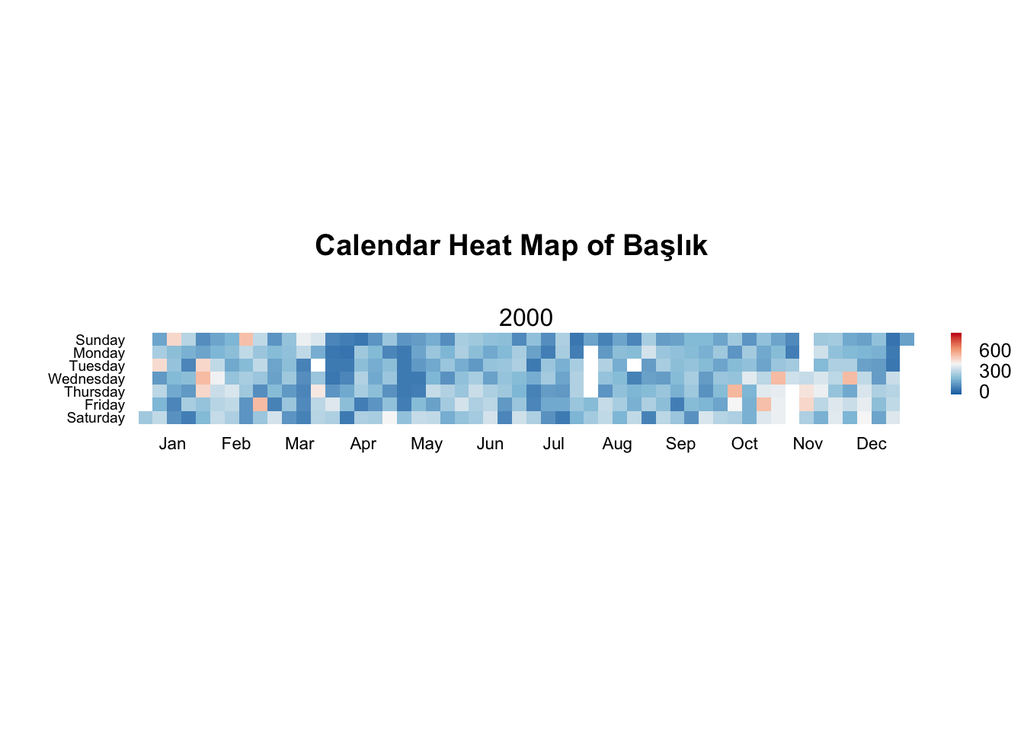

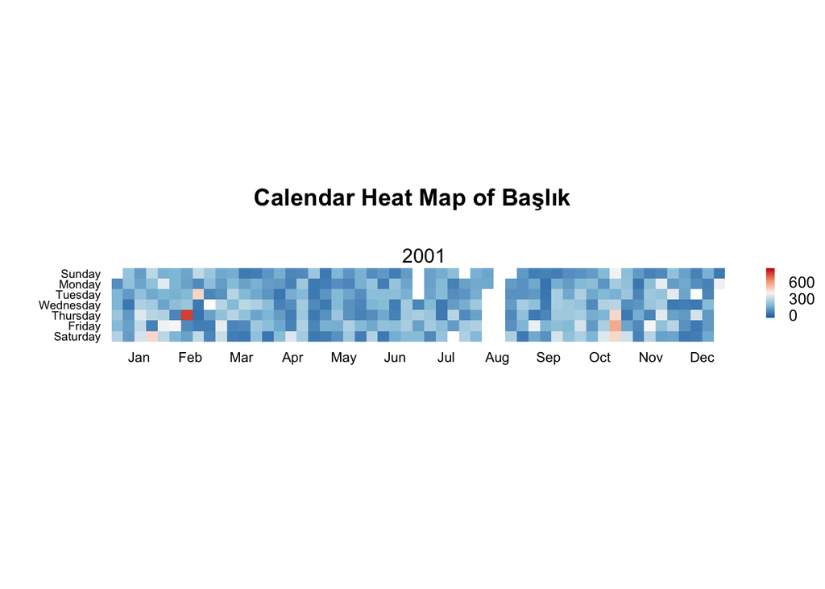

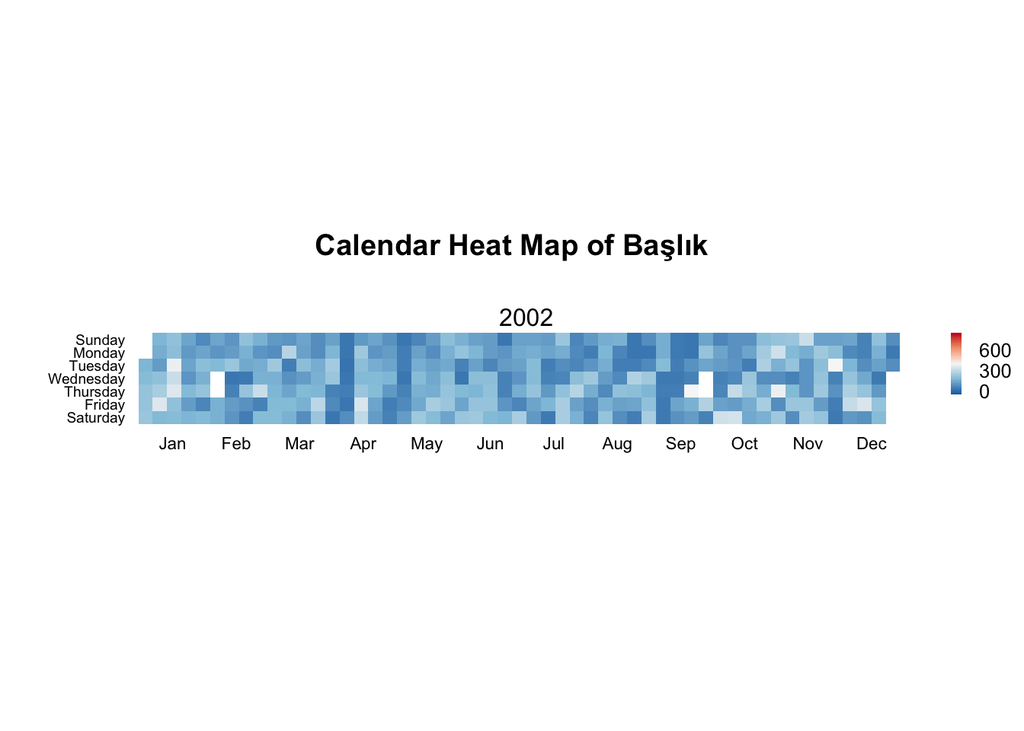

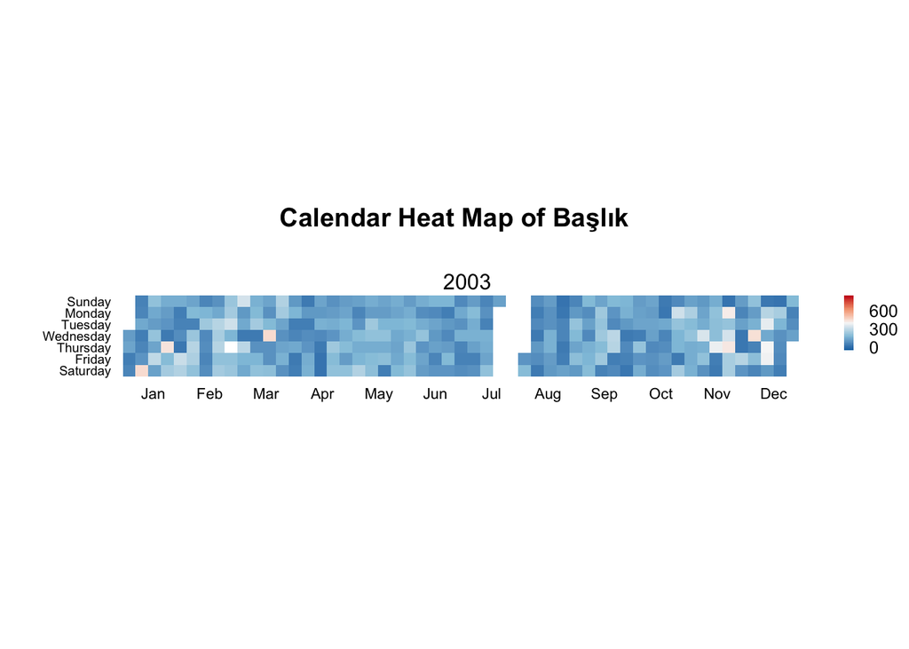

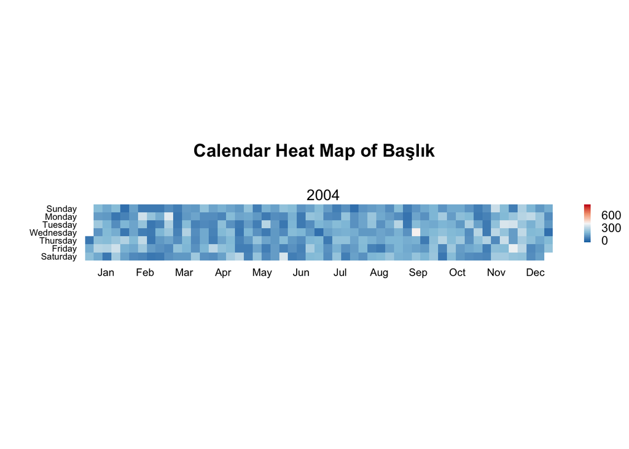

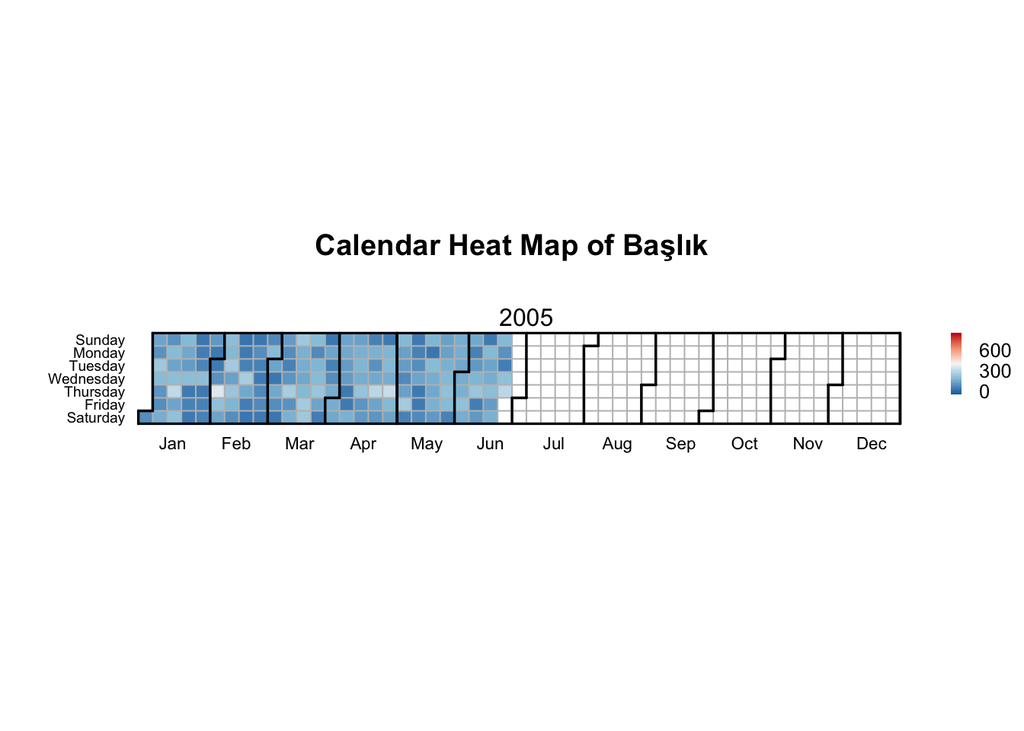

```r
calendarHeat(mydata$date, values = mydata$nox,color = "r2b" ,varname = "Başlık")
```

## 2.1 openair paketi

Hava kalitesi için geliştirilmiş olan bu paket, takvim ısı grafiği oluşturmak için `calendarPlot()`fonksiyonu argümanlarda değişiklik yapılarak kullanılır.

```r
calendarPlot(mydata, pollutant = "nox", year = 2003, month = 1:12, type = "default",
             annotate = "date", statistic = "mean", cols = "heat",
             limits = c(0, 100), lim = NULL, col.lim = c("grey30", "black"),
             col.arrow = "black", font.lim = c(1, 2), cex.lim = c(0.6, 1),
             digits = 0, data.thresh = 0, labels = NA, breaks = NA, w.shift = 0,
             remove.empty = TRUE, main = NULL, key.header = "", key.footer = "",
             key.position = "right", key = TRUE, auto.text = TRUE, ...)
```

```r
data(mydata)
head(mydata)
```

| date | ws | wd | nox | no2 | o3 | pm10 | so2 | co | pm25 |
| --- | --- | --- | --- | --- | --- | --- | --- | --- | --- |
| 1998-01-01 00:00:00 | 0.60 | 280 | 285 | 39 | 1 | 29 | 4.7225 | 3.3725 | NA |
| 1998-01-01 01:00:00 | 2.16 | 230 | NA | NA | NA | 37 | NA | NA | NA |
| 1998-01-01 02:00:00 | 2.76 | 190 | NA | NA | 3 | 34 | 6.8300 | 9.6025 | NA |
| 1998-01-01 03:00:00 | 2.16 | 170 | 493 | 52 | 3 | 35 | 7.6625 | 10.2175 | NA |
| 1998-01-01 04:00:00 | 2.40 | 180 | 468 | 78 | 2 | 34 | 8.0700 | 8.9125 | NA |
| 1998-01-01 05:00:00 | 3.00 | 190 | 264 | 42 | 0 | 16 | 5.5050 | 3.0525 | NA |

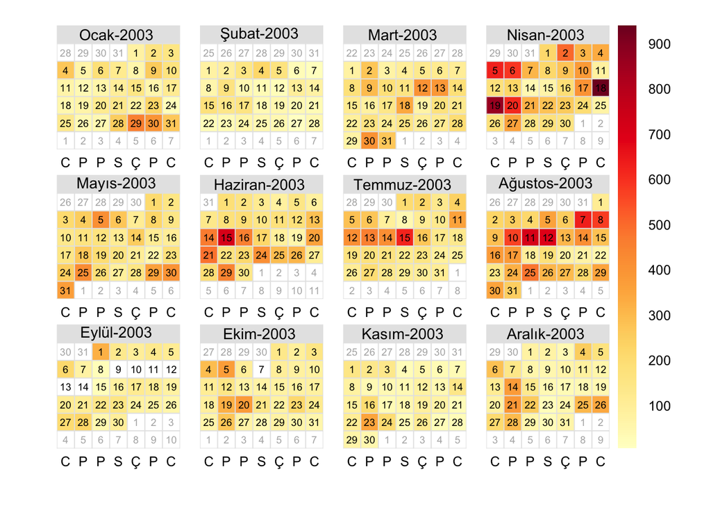

```r
openair::calendarPlot(mydata, pollutant = "o3", year = 2003, statistic = "sum")
```

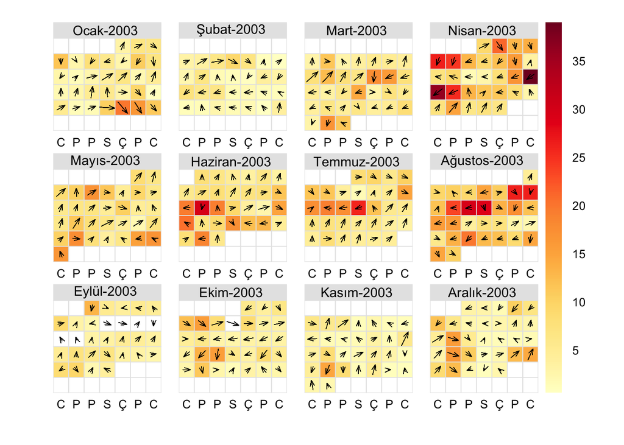

```r
calendarPlot(mydata, pollutant = "o3", year = 2003, annotate = "ws",cols = "heat")
```

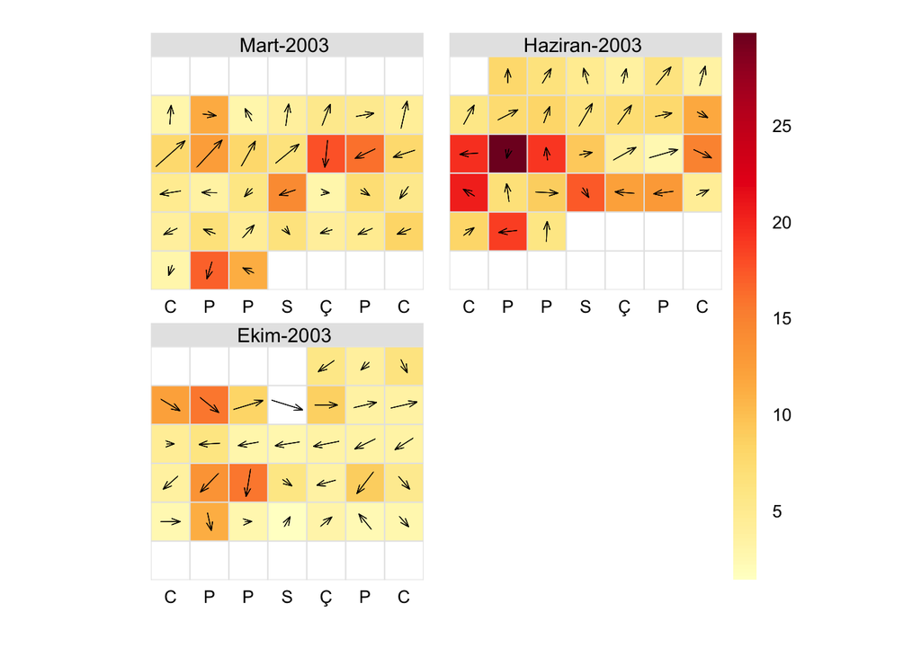

```r
calendarPlot(selectByDate(mydata, month = c(3,6,10), year = 2003), pollutant = "o3", year = 2003, annotate = "ws", cols = "heat")
```

# 3 İnteraktif takvim

interaktif takvim için `googleVis` paketi ile gerçekleştirilir.

```r
cl1 <- gvisCalendar(mydata, datevar="date", numvar="ws")
plot(cl1)
```

# Kaynaklar

Carslaw, David C., and Karl Ropkins. 2012. “Openair — an r Package for Air Quality Data Analysis.” *Environmental Modelling & Software* 27–28 (0): 52–61. https://doi.org/10.1016/j.envsoft.2011.09.008.

Gesmann, Markus, and Diego de Castillo. 2011. “googleVis: Interface Between r and the Google Visualisation API.” *The R Journal* 3 (2): 40–44. https://journal.r-project.org/archive/2011-2/RJournal_2011-2_Gesmann+de~Castillo.pdf.

Lovelace, Robin, and Layik Hama. 2019. *Calendar: Create, Read, Write, and Work with ’iCalander’ Files, Calendarsand Scheduling Data*. https://CRAN.R-project.org/package=calendar.

Mintz, D, T Fitz-Simons, and M Wayland. 1997. “Tracking Air Quality Trends with SAS/GRAPH.” In *Proceedings of the 22nd Annual SAS User Group International Conference (SUGI’97)*, 807–12.

Murrell, Paul. 2018. *R Graphics*. CRC Press.

Soage González, José Carlos, and Natalia Pérez Veiga. 2020. *calendR: Ready to Print Monthly and Yearly Calendars Made with ’Ggplot2’*. https://CRAN.R-project.org/package=calendR.

Wang, Earo, Dianne Cook, and Rob J Hyndman. 2020. “Calendar-Based Graphics for Visualizing People’s Daily Schedules.” *Journal of Computational and Graphical Statistics* 29 (3): 490–502.